# 시각화를 위한 함수

Dohye Kim

2019년 4월 19일

```r
library(ggplot2)
library(dplyr)
smdt = data.frame(stuno=1:5,
                  Korean=sample(60:100, 5),
                  English=sample((5:10)*10, 5),
                  Math=sample(50:100, 5))
head(smdt)
```

```
##   stuno Korean English Math
## 1     1     86     100   87
## 2     2     90      60   81
## 3     3     76      70   70
## 4     4     80      50   98
## 5     5     89      90   93
```

## 1. 산점도

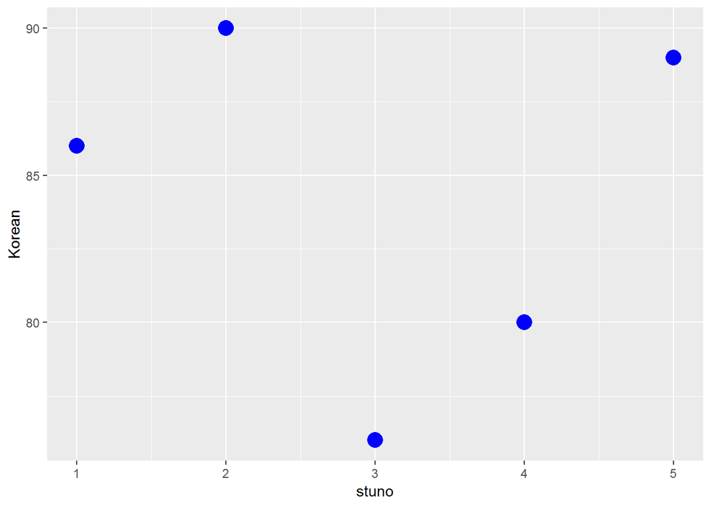

```r
ggplot() +
  geom_point(data=smdt,
             aes(x=stuno, y=Korean),
             color='blue', size = 5)
```

##### smdt 데이터를 활용해 학생의 국어 점수를 나타낸 그래프이다.

##### 위 그래프는 다음과 같이 쓸 수도 있다.

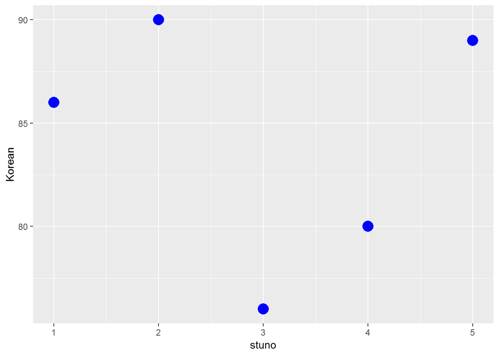

```r
ggplot(data=smdt) +
  geom_point(
             aes(x=stuno, y=Korean),
             color='blue', size = 5)
```

##### aes() 안에 color를 주게 되면 변수의 개수만큼 색이 정해진다.

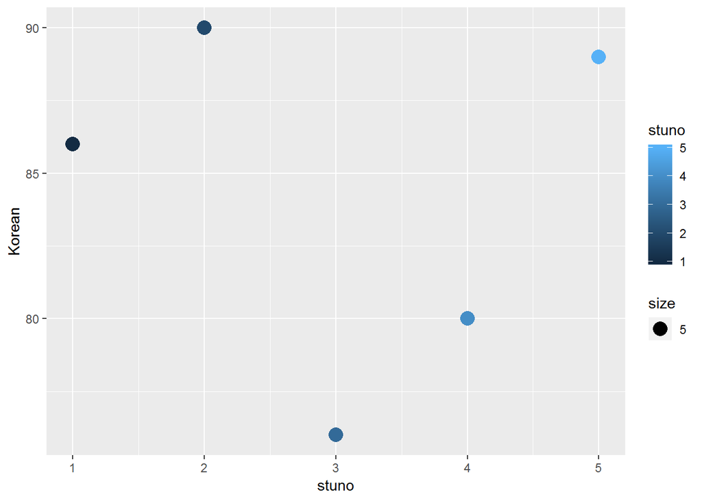

```r
ggplot() +
  geom_point(data=smdt,
             aes(x=stuno, y=Korean, color=stuno, size=5))
```

## 2. 꺾은선 그래프

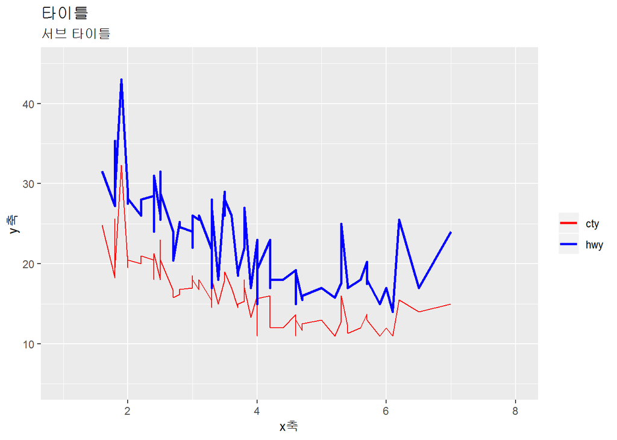

```r
d2 = ggplot2::mpg %>% group_by(manufacturer, displ) %>%
  summarise(m1 = mean(cty), m2 = mean(hwy))
ggplot(d2, aes(x=displ)) +
  geom_line(aes(y=m1, color='cty')) +
  geom_line(aes(y=m2, color='hwy'), size=1) +
  scale_colour_manual("", breaks = c("cty", "hwy"),
                      values = c("red", "blue")) +
  xlab("x축") +
  xlim(1, 8) +
  scale_y_continuous("y축", limits = c(5, 45)) +
  labs(title = '타이틀', subtitle = '서브 타이틀')
```

##### - ggplot2의 내장된 데이터 mpg를 사용해 배기량에 따른 도시, 고속도로 평균 연비를 나타낸 그래프이다.

##### - scale_colour_namual()은 직접 범례별 색을 정해주는 함수이다.

##### - xlab()은 x축의 이름을, xlim()은 x축의 범위를 나타낸다.

##### - ylab()과 ylim()은 scale_y_continuous([y축이름], limits=[범위])로 한 번에 나타낼 수 있다.

##### - labs() 를 통해 제목과 부제를 표현할 수 있다.

##### - data가 뭉친 곳의 꺾임을 줄이기 위해서 summarise()에서 mean함수를 사용했다.

## 3. 히스토그램

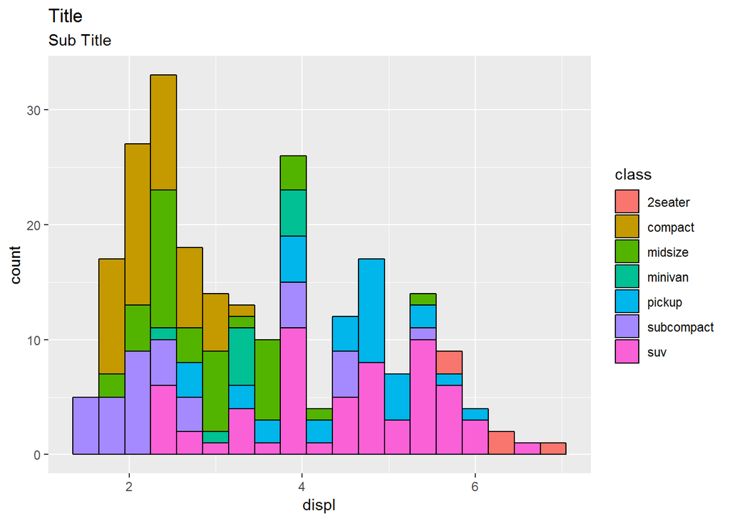

```r
ggplot(ggplot2::mpg, aes(displ)) +
  geom_histogram(aes(fill=class),
                 binwidth = .3,
                 col='black',
                 size=.5) +
  labs(title = 'Title', subtitle = 'Sub Title')
```

##### - histogram에서는 x축에 대한 data만 넘기면 되기 때문에 aes([x축데이터])로 구성한다.

##### - binwidth 옵션은 막대의 넓이를 정한다.

##### - col 옵션은 막대 선의 색을 정한다.

##### - size 옵션은 막대 선의 굵기를 정한다.

## 4. 막대그래프

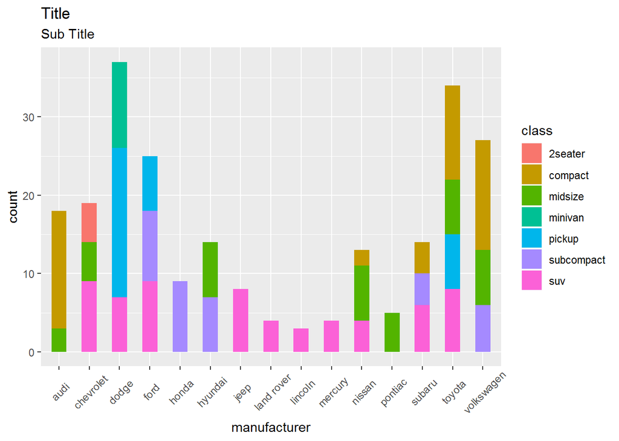

```r
ggplot(ggplot2::mpg, aes(manufacturer)) +
  geom_bar(aes(fill=class),
           width = 0.5) +
  theme(axis.text.x = element_text(angle=45,
                                   vjust=0.6)) +
  scale_fill_discrete(name = "class") +
  labs(title = 'Title', subtitle = 'Sub Title')
```

##### - ggplot2의 내장된 데이터 mpg를 사용해 제조사별 차종의 수를 나타낸 막대그래프이다.

##### - fill 옵션에는 기준이 되는 값을 입력한다.

##### - width 옵션은 막대의 넓이를 정한다.

##### - theme()의 angle은 글씨의 기울기를, vjust는 글씨가 아래에서부터 떨어진 정도를 의미한다.

##### - scale_fill_discrete()의 name 옵션은 범례의 이름을 정한다.

## 5. 밀도그래프

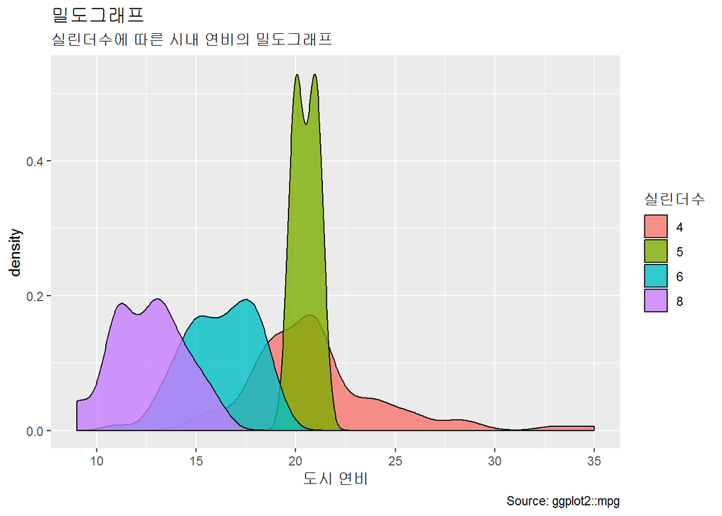

```r
ggplot(ggplot2::mpg, aes(cty)) +
  geom_density(aes(fill=factor(cyl)), alpha=0.8) +
  labs(title="밀도그래프", subtitle = "실린더수에 따른 시내 연비의 밀도그래프",
       caption="Source: ggplot2::mpg",
       x = "도시 연비",
       fill = "실린더수")
```

##### - ggplot2의 내장된 데이터 mpg를 사용해 실린더수에 따른 시내 연비를 나타낸 밀도그래프이다.

##### - aes()의 fill 옵션에는 class가 factor인 데이터가 들어가한 한다. 밀도는 연속형이 아니기 때문이다.

##### - labs()의 fill 옵션은 범례의 이름을 정한다.